# AFC - TD - *correction*

## Commerces de Paris

La mairie de Paris met à disposition, sur son site [Open Data](http://opendata.paris.fr), l’ensemble des [commerces de Paris](https://opendata.paris.fr/explore/dataset/commercesparis/), en 2014. Les données sont disponibles dans le fichier `commercesparis.csv`. Les informations sur les variables sont disponibles sur le site.

Il existe 18 groupes d’activités, déterminés semble-t’il par les deux premières lettres de chaque activité. Nous avons donc décidé de leur attribuer un nom, au regard des activités présentes dans chaque groupe.

| CODE | ACTIVITE |
| --- | --- |
| AA | Locaux non utilisés |
| AB | Commerces de gros |
| AC | Imprimeries, Services annexes, Studios reportages |
| AD | Activités de santé |
| AE | Lieux de spectacle |
| AF | Bureaux, équipements, ateliers, stockages (en boutique) |
| CA | Alimentaire |
| CB | Mode |
| CC | Pharmacies et produits de santé |
| CD | Equipements |
| CE | Ventes diverses |
| CF | Bricolage, jardinage |
| CG | Automobile, moto |
| CH | Restauration |
| CI | Hôtelerie |
| GM | Grands magasins |
| SA | Services diverses |
| SB | Banques |

## Arrondissements vs Activité

Dans ce TD, nous nous posons donc la question de savoir si les arrondissements ont des spécificités par rapport aux activités des commerces présents dans ceux-ci. Pour cela, nous allons donc croiser ces deux informations.

### Table de contingence

Nous devons donc tout d’abord créer la table de contingence que nous allons étudier à l’aide de l’AFC, table présentée ci-dessous. Il est bien évidemment difficile de déduire quoique ce soit à partir de cette table.

| Activité | 1 | 2 | 3 | 4 | 5 | 6 | 7 | 8 | 9 | 10 | 11 | 12 | 13 | 14 | 15 | 16 | 17 | 18 | 19 | 20 |
| --- | --- | --- | --- | --- | --- | --- | --- | --- | --- | --- | --- | --- | --- | --- | --- | --- | --- | --- | --- | --- |
| Locaux non utilisés | 390 | 336 | 349 | 143 | 221 | 152 | 124 | 238 | 408 | 587 | 729 | 372 | 283 | 287 | 461 | 223 | 534 | 804 | 428 | 590 |
| Commerces de gros | 2 | 552 | 607 | 21 | 3 | 9 | 2 | 4 | 17 | 172 | 479 | 21 | 20 | 7 | 16 | 5 | 12 | 24 | 18 | 11 |
| Imprimeries, Services annexes, Studios reportages | 3 | 21 | 9 | 11 | 15 | 17 | 7 | 16 | 22 | 58 | 49 | 21 | 26 | 24 | 46 | 17 | 61 | 55 | 24 | 35 |
| Activités de santé | 16 | 21 | 23 | 21 | 80 | 31 | 42 | 31 | 68 | 72 | 144 | 149 | 114 | 119 | 207 | 70 | 155 | 159 | 108 | 133 |
| Lieux de spectacle | 4 | 11 | 13 | 7 | 5 | 7 | 3 | 13 | 28 | 14 | 25 | 8 | 5 | 7 | 4 | 2 | 5 | 27 | 16 | 17 |
| Bureaux, équipements, ateliers, stockages (en boutique) | 137 | 283 | 320 | 176 | 267 | 171 | 216 | 183 | 476 | 657 | 1146 | 605 | 502 | 553 | 763 | 286 | 862 | 925 | 394 | 624 |
| Alimentaire | 119 | 121 | 153 | 187 | 288 | 217 | 222 | 224 | 334 | 432 | 500 | 412 | 392 | 385 | 621 | 454 | 584 | 706 | 408 | 455 |
| Mode | 777 | 400 | 457 | 496 | 184 | 899 | 342 | 797 | 488 | 427 | 373 | 237 | 202 | 264 | 458 | 557 | 547 | 531 | 150 | 181 |
| Pharmacies et produits de santé | 104 | 64 | 66 | 91 | 86 | 134 | 87 | 152 | 153 | 154 | 157 | 141 | 130 | 123 | 214 | 177 | 213 | 213 | 117 | 130 |
| Equipements | 133 | 56 | 77 | 124 | 79 | 201 | 315 | 182 | 160 | 104 | 235 | 163 | 76 | 113 | 295 | 152 | 183 | 335 | 70 | 108 |
| Ventes diverses | 235 | 180 | 334 | 267 | 389 | 509 | 217 | 343 | 397 | 255 | 390 | 309 | 217 | 211 | 340 | 179 | 276 | 418 | 136 | 196 |
| Bricolage, jardinage | 22 | 17 | 23 | 27 | 36 | 35 | 52 | 36 | 28 | 42 | 89 | 67 | 37 | 42 | 91 | 74 | 85 | 60 | 30 | 46 |
| Automobile, moto | 6 | 8 | 15 | 6 | 21 | 4 | 18 | 35 | 16 | 54 | 96 | 69 | 57 | 42 | 98 | 90 | 129 | 66 | 43 | 60 |
| Restauration | 581 | 567 | 352 | 430 | 753 | 573 | 349 | 844 | 1023 | 877 | 1116 | 669 | 628 | 595 | 893 | 529 | 909 | 1038 | 532 | 565 |
| Hôtelerie | 75 | 45 | 33 | 37 | 90 | 105 | 63 | 135 | 184 | 148 | 113 | 96 | 58 | 106 | 111 | 73 | 161 | 140 | 44 | 54 |
| Grands magasins | 1 | 0 | 0 | 1 | 0 | 0 | 1 | 0 | 2 | 0 | 0 | 0 | 1 | 0 | 1 | 0 | 0 | 0 | 0 | 1 |
| Services diverses | 242 | 284 | 248 | 196 | 399 | 330 | 309 | 512 | 705 | 752 | 1036 | 841 | 604 | 675 | 1235 | 768 | 1074 | 938 | 507 | 688 |
| Banques | 89 | 101 | 98 | 87 | 141 | 132 | 167 | 238 | 251 | 274 | 300 | 282 | 211 | 228 | 395 | 335 | 429 | 375 | 195 | 225 |

### Description rapide

Les commerces sont situés principalement dans les arrondissements 11 et 18, ainsi que 17 et 15. Les arrondissements 4 et 7 sont ceux avec le moins d’établissements.

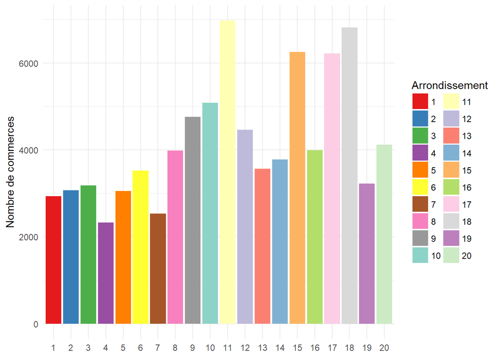

Certaines activités sont beaucoup plus présentes que d’autres. En particulier, il y a très peu de grands magasins et de lieux de spectacle. Par contre, il y a beaucoup de restaurants et d’entreprises de services diverses.

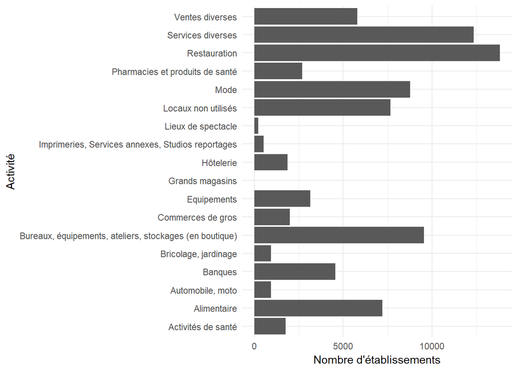

On remarque clairement que les commerces de gros ne sont situés quasiment que peu d’arrondissements (2, 3 et 11). De même pour les grands magasins (mais il n’y en a que 8).

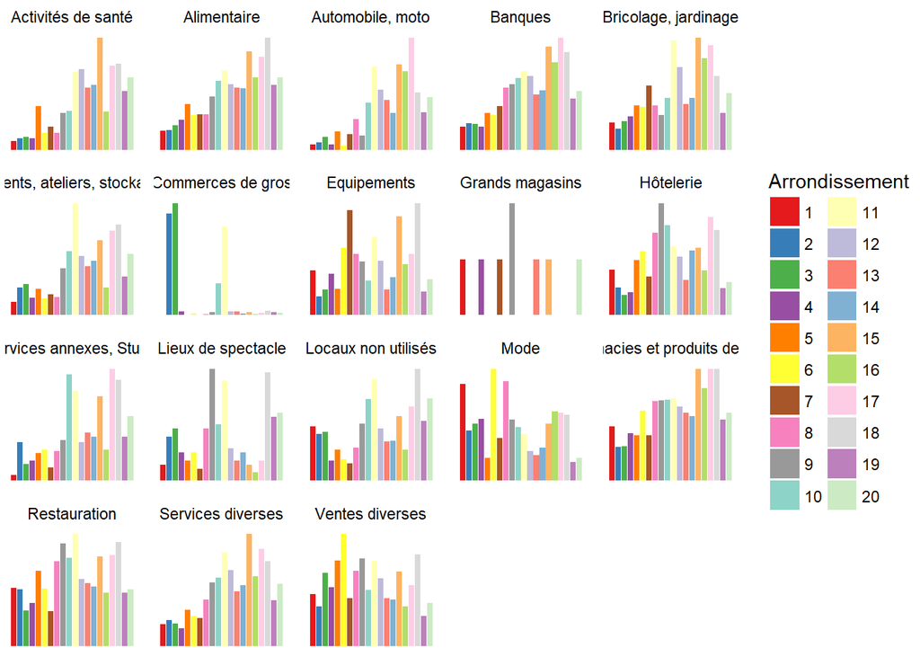

En réalisant le graphique *dual*, nous arrivons à peu près aux mêmes conclusions.

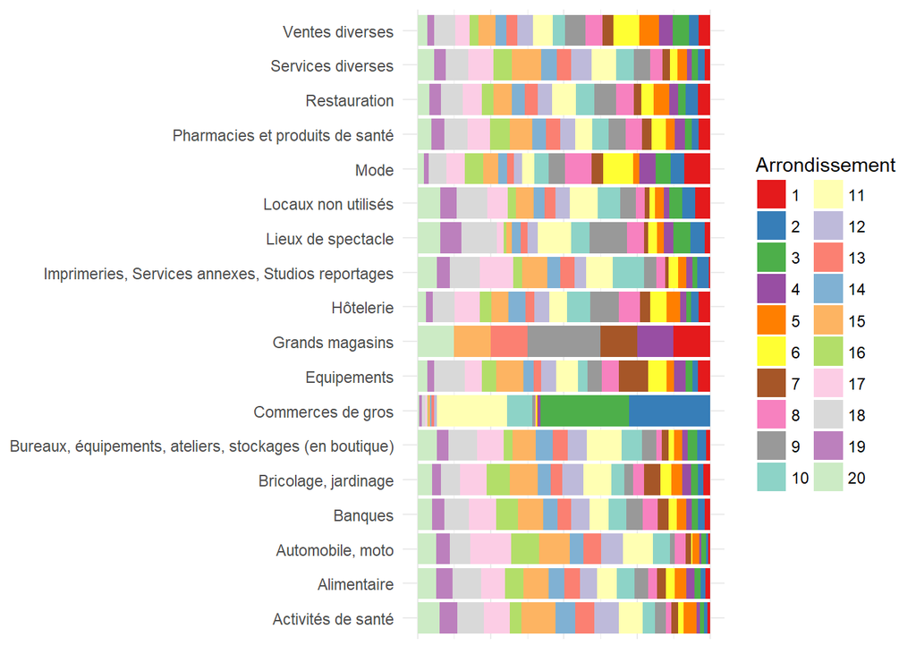

Mais il est bien difficile, à l’aide de ces graphiques, de faire de réelles conclusions sur le lien entre le type d’activité et l’arrondissement.

### Réalisation de l’AFC

Pour aller plus loin, et ainsi mieux rendre compte du lien entre ces deux informations, nous devons utiliser une Analyse Factorielle des Correspondances (**AFC**).

> Que peut-on dire globalement ?

2 dimensions à garder (83% de variance expliquée). Les autres axes n’apportent que très peu d’informations.

|  | eigenvalue | percentage of variance | cumulative percentage of variance |
| --- | --- | --- | --- |
| dim 1 | 0.11 | 52.64 | 52.64 |
| dim 2 | 0.07 | 30.20 | 82.85 |
| dim 3 | 0.01 | 5.38 | 88.23 |
| dim 4 | 0.01 | 3.92 | 92.15 |
| dim 5 | 0.01 | 3.25 | 95.40 |

Quelques activités ressortent du lot, ainsi que des arrondissements (cf plus bas). Mais la lecture est difficile.

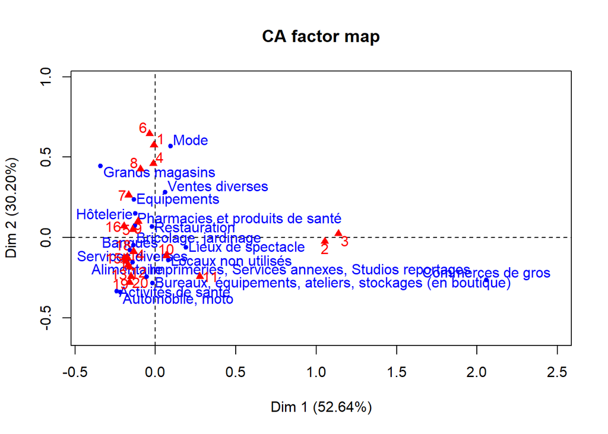

Nous allons nous concentrer sur les modalités qui contribuent fortement à la création d’un des deux axes, afin de ne présenter que celles-ci.

A l’aide du tableau ci-après, nous remarquons que c’est l’activité *Commerces de gros* qui créé l’axe 1, même si certaines autres activités sont bien représentés sur cet axe (*Santé*, *Banques*, *Alimentaire*). L’axe 2 est quand à lui expliqué quasi uniquement par l’activité *Mode*. Mais la aussi, les activités suivantes sont bien projetés sur cet axe : *Bureaux, équipements, ateliers, stockages (en boutique)*, *Ventes diverses*, et *Activités de santé*.

|  | Contrib 1 | Contrib 2 | Qualité 1 | Qualité 2 |
| --- | --- | --- | --- | --- |
| Locaux non utilisés | 1 | 3 | 7 | 22 |
| Commerces de gros | 89 | 3 | 98 | 2 |
| Imprimeries, Services annexes, Studios reportages | 0 | 1 | 2 | 41 |
| Activités de santé | 1 | 4 | 28 | 53 |
| Lieux de spectacle | 0 | 0 | 11 | 1 |
| Bureaux, équipements, ateliers, stockages (en boutique) | 0 | 14 | 0 | 83 |
| Alimentaire | 2 | 3 | 43 | 32 |
| Mode | 1 | 52 | 3 | 91 |
| Pharmacies et produits de santé | 0 | 0 | 53 | 17 |
| Equipements | 1 | 3 | 7 | 23 |
| Ventes diverses | 0 | 8 | 3 | 54 |
| Bricolage, jardinage | 0 | 0 | 18 | 2 |
| Automobile, moto | 0 | 2 | 16 | 40 |
| Restauration | 0 | 1 | 1 | 14 |
| Hôtelerie | 0 | 1 | 14 | 20 |
| Grands magasins | 0 | 0 | 5 | 8 |
| Services diverses | 3 | 5 | 35 | 42 |
| Banques | 1 | 1 | 44 | 11 |

|  | Contrib 1 | Contrib 2 | Qualité 1 | Qualité 2 |
| --- | --- | --- | --- | --- |
| 1 | 0 | 18 | 0 | 78 |
| 2 | 36 | 0 | 98 | 0 |
| 3 | 43 | 0 | 98 | 0 |
| 4 | 0 | 9 | 0 | 90 |
| 5 | 1 | 0 | 13 | 2 |
| 6 | 0 | 27 | 0 | 94 |
| 7 | 1 | 3 | 10 | 24 |
| 8 | 0 | 13 | 4 | 86 |
| 9 | 1 | 1 | 17 | 15 |
| 10 | 0 | 1 | 12 | 32 |
| 11 | 6 | 7 | 52 | 40 |
| 12 | 1 | 2 | 41 | 42 |
| 13 | 1 | 2 | 34 | 46 |
| 14 | 1 | 1 | 51 | 33 |
| 15 | 2 | 2 | 51 | 22 |
| 16 | 2 | 0 | 27 | 4 |
| 17 | 2 | 2 | 49 | 23 |
| 18 | 1 | 1 | 38 | 16 |
| 19 | 1 | 3 | 20 | 50 |
| 20 | 1 | 6 | 20 | 58 |

Nous pouvons donc refaire deux graphiques, en se concentrant sur la qualité de représentation de celles-ci sur chaque axe.

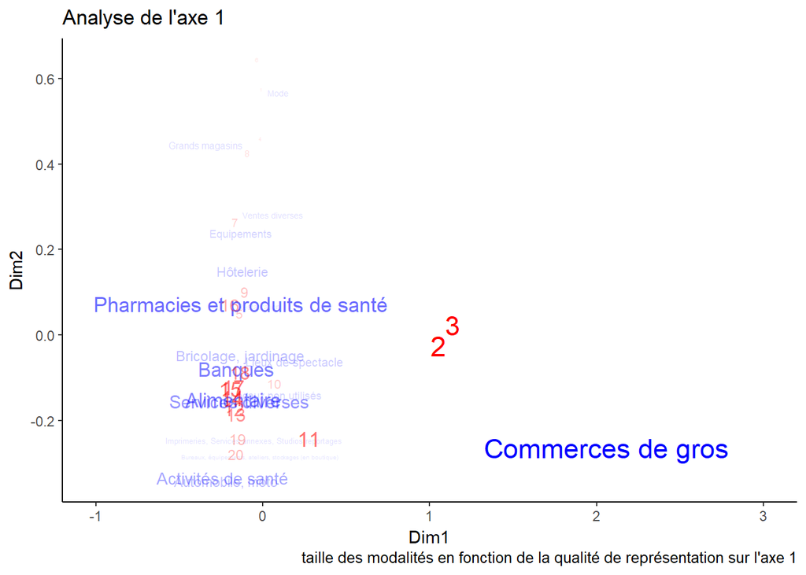

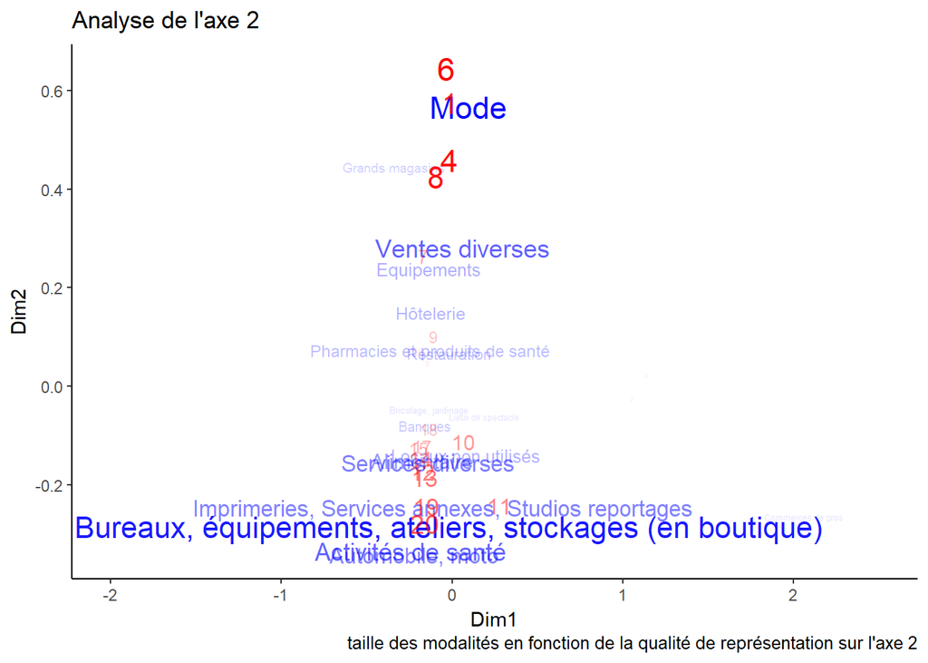

Pour une analyse plus fine, il faudrait d’une part mettre de côté les commerces de gros, qui influent beaucoup trop fortement l’analyse. Ensuite, pour chaque groupe d’activité, nous pourrions faire la même analyse.